# Assignment 4

Sidney Gerst, Natalie Dornan

May 30, 2019

### 1. Marginal Cost of Abatement

#### Sector A

$Marginal~Cost~of~Abatement~Sector~A = 0.5768419*q + -8.6444767$

#### Sector B

$Marginal~Cost~of~Abatement~Sector~B = 0.1987443*q + 9.3176977$

#### Sector C

$Marginal~Cost~of~Abatement~Sector~C = 0.7838266*q + -11.6550307$

#### Table of the regression coefficients

**Table 1. Marginal abatement cost function for each sector.**

|  | *Dependent variable:* |  |  |  |
| --- | --- | --- | --- | --- |
|  | A | B | C | D |
|  | (1) | (2) | (3) | (4) |
| Abatement | 0.577*** | 0.199*** | 0.784*** | 0.260*** |
|  | (0.048) | (0.046) | (0.079) | (0.064) |
| Constant | -8.644* | 9.318** | -11.655 | 9.688 |
|  | (4.257) | (4.091) | (6.963) | (5.606) |
| AIC | 119.3 | 118 | 135 | 128.1 |
| Observations | 16 | 16 | 16 | 16 |
| R<sup>2</sup> | 0.910 | 0.566 | 0.875 | 0.543 |
| Adjusted R<sup>2</sup> | 0.904 | 0.535 | 0.866 | 0.511 |
| Residual Std. Error (df = 14) | 8.917 | 8.569 | 14.584 | 11.742 |
| F Statistic (df = 1; 14) | 142.288*** | 18.291*** | 98.214*** | 16.661*** |
| *Note:* | p<0.1; p<0.05; p<0.01 |  |  |  |

#### Plot all Abatement Curves

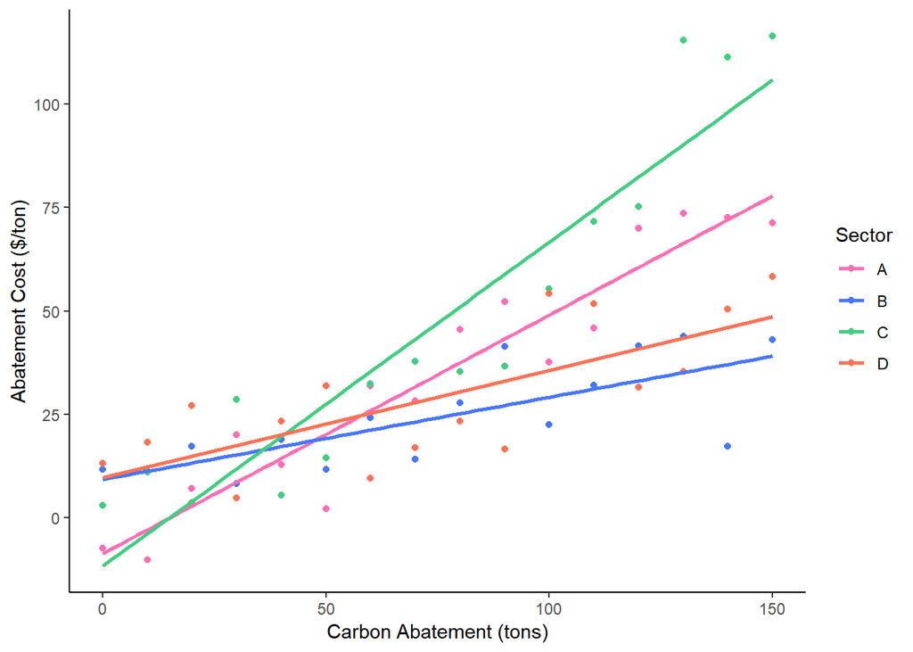

### 2. Demand Curves of carbon emissions

##### Sector A

Plugging in 0 for q will result in the willingness to pay for the right to pollute the first unit. Sector A: $Price~of~Emissions = 0.5768419*(180-q) + -8.6444767$  
$Willingness~to~Pay~for~First~Unit = \$95.2$

#### Combined Demand Curves

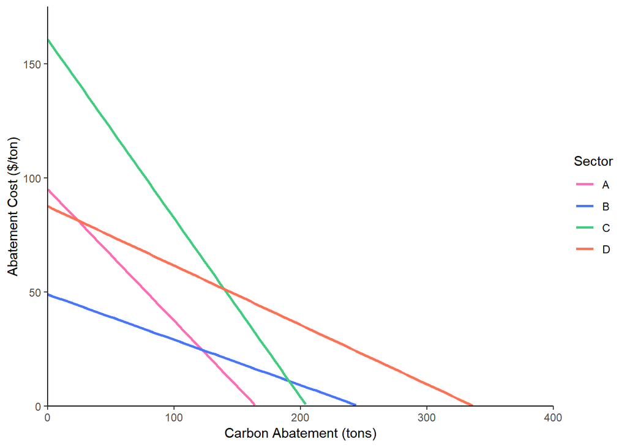

### 3. Country X

##### A. Cap on Carbon.

1. Total Cost of Carbon Cap

$Total~Cost = 6698.88$

2. Cost to each Sector

$Cost~to~Sector~A = 2019.76$

$Cost~to~Sector~B = 1925.49$

$Cost~to~Sector~C = 2753.63$

3. There is no tax revenue with a cap on carbon

##### B. Tax on Carbon

1. Total Cost of Carbon Tax

$Total~Cost = 5879.81$

2. Cost to each Sector

$Cost~to~Sector~A = 1282.61$

$Cost~to~Sector~B = 3692.27$

$Cost~to~Sector~C = 904.93$

3. Total Tax Revenue

$Total~Tax~Revenue = 1.182797\times 10^{4}$

##### C. Cap and Trade

1. Total Cost of Carbon Cap and Trade

$Total~Cost = 5879.81$

2. Cost to each sector

$Cost~to~Sector~A = 1941.04$

$Cost~to~Sector~B = 1661.8$

$Cost~to~Sector~C = 2276.97$

3. Total Tax Revenue. Not applicable, no tax in Cap and Trade.

### 4. Country Y

A will buy 993.89 with a final abatement of 1698.99

B will sell -91.53 with a final abatement of 1924.55

C will buy 1403.96 with a final abatement of 1883.88

D will sell -2306.32 with a final abatement of -778.32

### 5. Air Pollution

##### a. Cap and trade market only covering x, how much pollution in X and Y?

There are 300 tons of pollution for both Country X and Y

##### b. Country Y enters Coutnry X market

Country X increases pollution (377.39 tons) and Country Y decreases pollution (222.61 tons).

##### c. Advice

Net pollution is equal, but there will be an unequal distribution of local pollution depending on how the trade is conducted because Country Y will have a sold credits to Country X.